# Age-from-stage analyses

Patrick Barks

2024-12-21

## Introduction

Regardless of whether the stage classes of a matrix population model (MPM) are based on age, size, and/or ontogeny, it’s possible to obtain age-specific schedules of survivorship (lx) and reproduction (mx) using ‘age-from-stage’ methods, as described by Caswell (2001).

## Preliminaries

We’ll start by loading a few packages and a dataset that we’ll be using throughout this vignette.

```r
library(Rage) # load Rage
data(mpm1) # load data object 'mpm1'
mpm1 # display the contents
```

```
#> $matU
#>         seed small medium large dormant
#> seed    0.10  0.00   0.00  0.00    0.00
#> small   0.05  0.12   0.10  0.00    0.00
#> medium  0.00  0.35   0.12  0.23    0.12
#> large   0.00  0.03   0.28  0.52    0.10
#> dormant 0.00  0.00   0.16  0.11    0.17
#>
#> $matF
#>         seed small medium large dormant
#> seed       0     0   17.9  45.6       0
#> small      0     0    0.0   0.0       0
#> medium     0     0    0.0   0.0       0
#> large      0     0    0.0   0.0       0
#> dormant    0     0    0.0   0.0       0
```

## Age-from-stage methods with a single matrix population model

This MPM has 5 stage class, and it’s apparent from the `dimnames` attribute that the stages are not based solely on age. Nonetheless, we can estimate age-schedules of survivorship and reproduction using the functions `mpm_to_lx()` and `mpm_to_mx()` from `Rage`.

```r
dimnames(mpm1$matU)
```

```
#> [[1]]
#> [1] "seed"    "small"   "medium"  "large"   "dormant"
#>
#> [[2]]
#> [1] "seed"    "small"   "medium"  "large"   "dormant"
```

```r
# extract U and F matrices
mat_U <- mpm1$matU
mat_F <- mpm1$matF

# calculate lx
lx <- mpm_to_lx(mat_U, start = 1, xmax = 30)

# calculate mx
mx <- mpm_to_mx(mat_U, mat_F, start = 1, xmax = 30)
```

```r
# calculate lx
lx <- mpm_to_lx(mat_U, start = 1, xmax = 30)

# calculate mx
mx <- mpm_to_mx(mat_U, mat_F, start = 1, xmax = 30)
```

Let’s take a look at the trajectories.

[figure not shown]

```r
plot(lx, ylim = c(0, 1), type = "l", xlab = "Age")
```

[figure not shown]

```r
plot(mx, type = "l", xlab = "Age")
```

## Extending to many matrix population models

Now we’ll extend the basic approach above to many models. Specifically, we’ll examine trajectories of survivorship for all of the tree species in `Compadre`. `Compadre` is a database of matrix population models. You can read more about it [here](https://compadre-db.org/), and the associated *R* package [here](https://jonesor.github.io/Rcompadre/). The `Rcompadre` package contains a subset of the database that we can use to demonstrate computations on many models simultaneously.

First, we’ll subset `Compadre` to our group of interest (`OrganismType == "Tree"`). We’ll also remove matrices with missing values, and limit our selection to matrices with a periodicity (i.e. transition interval) of 1 year.

```r
library(Rcompadre)
data(Compadre)

# In older versions of Com(p)adre the ProjectionInterval column was called
# AnnualPeriodicity.
if ("AnnualPeriodicity" %in% names(Compadre)) {
  Compadre$ProjectionInterval <- Compadre$AnnualPeriodicity
}

comp_flag <- cdb_flag(Compadre, "check_NA_U")

comp_use <- subset(comp_flag, OrganismType == "Tree" &
  check_NA_U == FALSE &
  ProjectionInterval == 1)
```

Let’s take a look at the species/populations that made the cut.

```r
CompadreData(comp_use)[, c(
  "SpeciesAccepted", "MatrixPopulation",
  "MatrixTreatment"
)]
```

```
#> # A tibble: 7 × 3
#>   SpeciesAccepted          MatrixPopulation                      MatrixTreatment
#>   <chr>                    <chr>                                 <chr>
#> 1 Phyllanthus indofischeri Biligiri Rangaswamy Temple Wildlife … Fruit harvesti…
#> 2 Phyllanthus indofischeri Biligiri Rangaswamy Temple Wildlife … Fruit harvesti…
#> 3 Castanea dentata         Leelanau                              Unmanipulated
#> 4 Phyllanthus emblica      Biligiri Rangaswamy Temple Wildlife … Time since las…
#> 5 Phyllanthus indofischeri Biligiri Rangaswamy Temple Wildlife … Unmanipulated
#> 6 Manilkara zapota         Central Veracruz state                Unmanipulated
#> 7 Rhododendron ponticum    Ockham Common Nature Reserve          Unmanipulated
```

Notice that there are 3 matrices for the species *Phyllanthus indofischeri*, reflecting different treatment groups. Let’s collapse these replicates down to a single matrix per species, by averaging the relevant MPMs using `cdb_collapse()`. We’ll also use the function `cdb_id_stages()`, to make sure we’re only collapsing matrices that have the same stage class definitions.

```r
# add column ID-ing matrices with same MatrixClassAuthor vector
comp_use$stage_id <- cdb_id_stages(comp_use)

# collapse database to single matrix per species * MatrixClassAuthor
comp_collapse <- cdb_collapse(comp_use, "stage_id")

# check species/populations again
CompadreData(comp_collapse)[, c(
  "SpeciesAccepted", "MatrixPopulation",
  "MatrixTreatment"
)]
```

```
#> # A tibble: 5 × 3
#>   SpeciesAccepted          MatrixPopulation                      MatrixTreatment
#>   <chr>                    <chr>                                 <chr>
#> 1 Phyllanthus indofischeri Biligiri Rangaswamy Temple Wildlife … Fruit harvesti…
#> 2 Castanea dentata         Leelanau                              Unmanipulated
#> 3 Phyllanthus emblica      Biligiri Rangaswamy Temple Wildlife … Time since las…
#> 4 Manilkara zapota         Central Veracruz state                Unmanipulated
#> 5 Rhododendron ponticum    Ockham Common Nature Reserve          Unmanipulated
```

Next, let’s look at the organized stage classes for each MPM. If any of our MPMs include propagule or dormant stage classes, we may want to account for them when calculating lx.

```r
MatrixClassOrganized(comp_collapse)
```

```
#> [[1]]
#> [1] "prop"   "active" "active" "active" "active" "active" "active"
#>
#> [[2]]
#> [1] "active" "active" "active" "active" "active" "active" "active" "active"
#>
#> [[3]]
#> [1] "active" "active" "active" "active" "active" "active"
#>
#> [[4]]
#> [1] "active" "active" "active" "active" "active" "active" "active" "active"
#> [9] "active"
#>
#> [[5]]
#> [1] "active" "active" "active" "active"
```

Indeed, 1 MPM includes a propagule stage. So let’s use the function `mpm_first_active()` to determine the first ‘active’ stage class for each MPM, which we’ll use to define the start of life.

```r
comp_collapse$start_life <- mpm_first_active(comp_collapse)
```

Finally, we’ll use `lapply()` to apply the function `mpm_to_lx` to each row of `comp_collapse`. By default, `lapply()` will return a vector for each row, and the length of which is `xmax`. We can convert the output to an matrix, with columns representing each row from `comp_collapse` using `do.call`. After that, we’ll use the function `matplot()` to plot age-trajectories of survivorship for each species.

```r
lx_list <- lapply(seq_len(nrow(comp_collapse)),
  function(x, comp_collapse) {
    U <- matU(comp_collapse$mat[[x]])

    rownames(U) <- colnames(U) # ensure row and col names are present

    mpm_to_lx(
      matU = U,
      start = comp_collapse$start_life[x],
      xmax = 40
    )
  },
  comp_collapse = comp_collapse
)

lx_array <- do.call(cbind, lx_list)
```

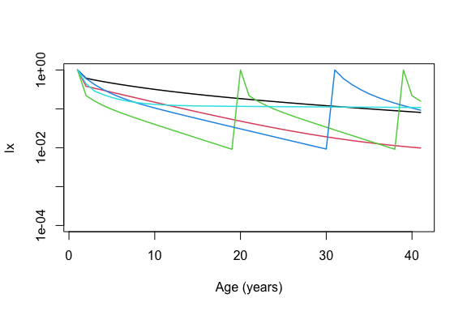

```r
matplot(lx_array,
  type = "l", lty = 1, log = "y", ylim = c(0.0001, 1),
  lwd = 1.5, xlab = "Age (years)", ylab = "lx"
)
```

## References

Caswell, H. (2001). Matrix Population Models: Construction, Analysis, and Interpretation. 2nd edition. Sinauer Associates, Sunderland, MA. ISBN-10: 0878930965